# Simulation Exercise

Chuck Chekuri

3/4/2017

## Overview

This is the final assignment for Statistical Inference course of Data Science Specialization by John Hopkins University.

This project report describes

1. Simulation exercise to illustrate the Central Limit Theorem

### Part 1. Simulation Exercise

This exercise demonstrates the Central Limit Theorem by simulating the mean and variance of an exponential distribution to compare that with the theoretical distribution. It also shows that the distribution of the mean of an exponential distribution follows a normal distribution.

#### Simulations

All simulations used a sample of 40 random exponentiall distributed numbers at a rate($\lambda$) of 0.2. Two simulations for calculating the average mean and average variance were performed and the average values from the simulations were compared with the theoretical mean and variance for the given rate($\lambda$) of 0.2

Additional three simulations were done to show the convergence of these averages to the normal distribution illustrating the Central Limit Theorem.

#### Comparing Sample Mean with Theoretical Mean

```r
lambda<-0.2;n<-40
nsim=1000
mns = NULL
for (i in 1 : nsim) mns = c(mns, mean(rexp(n, lambda)))
```

The above code calculates and stores the simulated sample means in the variable mns. Here is the histogram for the simulation after 1000 simulations. The blue vertical line shows the average sample mean 4.975 is very close the to the theoretical mean 1/$\lambda$ = 5.0.

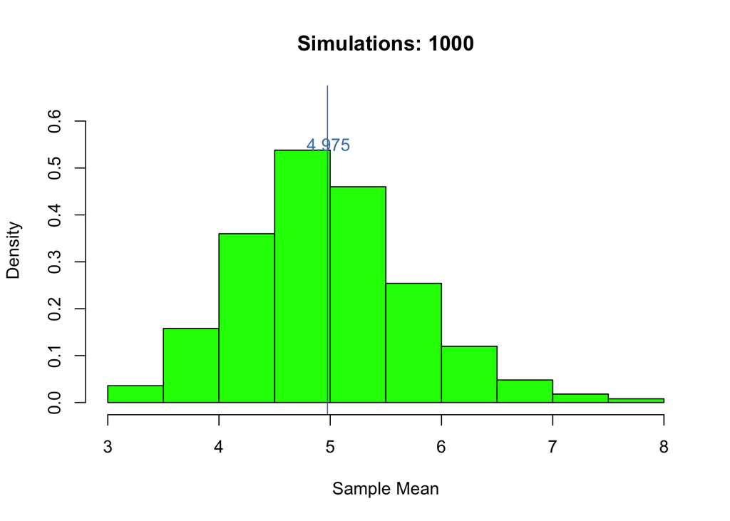

#### Comparing sample variance with theoretical variance

The code below gets the variances of an exponential distribution for 1000 simulations.

```r
vrs = NULL
for (i in 1 : nsim) vrs = c(vrs, var(rexp(n, lambda)))
```

The theoretical variance for an exponential distribution is $1/\lambda^2$ = 25 and the average variance of the sample means is $mean(vrs)$ = 25.1618297.

This shows the average variance of sample means 25.1618297 is close the theoretical mean 25.

#### Distribution of sample means is close to normal distribution

Simulating the sample means for 10, 100, 1000 times and drawing the density functions against a normal distribution for a large sample, the graphs show how the distribution (blueline) comes close to the normal distribution (black line).

The following code does the simulation.

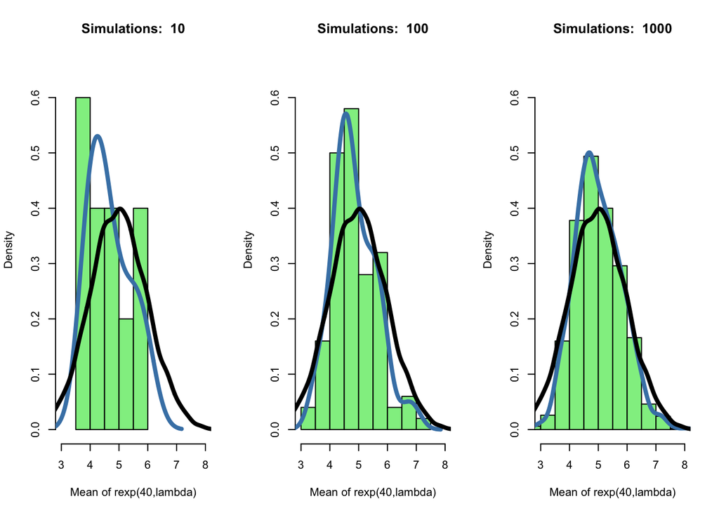

```r
set.seed(1999)
nd <- rnorm(10000, mean=mean(mns)) # shift to align the density plots
par(mfrow=c(1,3))
for (nsim in c(10,100,1000)){
  title<-paste("Simulations: ", nsim)
  mns = NULL
  for (i in 1 : nsim) mns = c(mns, mean(rexp(n, lambda)))

  hist(mns, probability = TRUE, col="lightgreen",
          ylim = c(0, .65), xlim = c(3,8),
       main=title, xlab="Mean of rexp(40,lambda)")
  lines(density(mns), lwd=4, col="steelblue")
  lines(density(nd), col="black", lwd=4)
}
```

#### Conclusion

The simulations successfuly show that the mean of exponential distribution follows a normal distribution and the results support the central limit theorem.